# Visualizing Data

September 09, 2016

## Overview

## Why Viz First?

Philosophy: start with the stuff you'll want

- so you'll stick around for the stuff you hate.

## Visual Exploration of Data

- Most important part of data exploration
- Ability to see trends and relationships is unmatched by any statistical summary
- One of the most important methods of communication
- Analysis often hinges on proper visual exploration

## Plotting Packages in R

- Lots of packages: base, lattice, ggplot2, others..
- In keeping with the philosophy of this tutorial, we will focus on ggplot2
- Two main functions: `ggplot()` and `qplot()`

```r
# Install if you haven't
# install.packages('ggplot2')
library(ggplot2)
```

## qplot()

## qplot: fast plotting

- qplot gives you fast plotting, at the expensive of customizability
- great for throwing ideas out quickly and exploring new possibilities

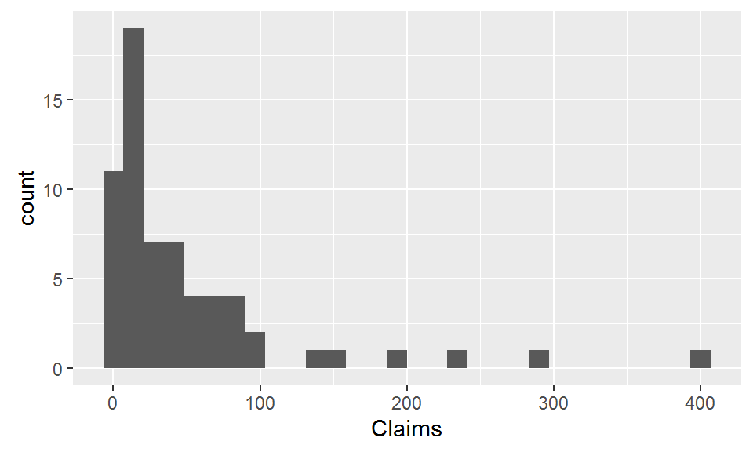

```r
library(MASS)

# Histogram is default for one variable
qplot(Claims, data = Insurance)
```

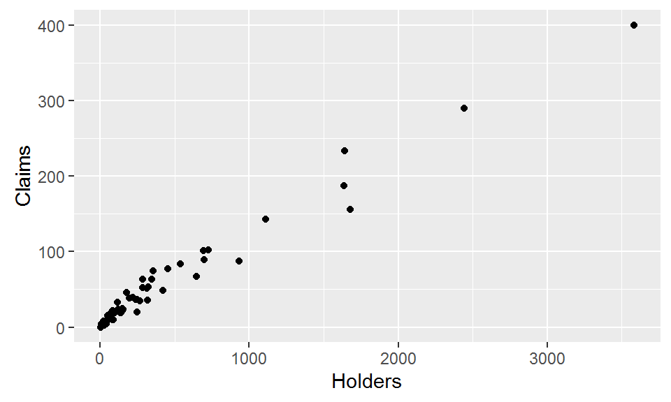

```r
# Scatterplot is default for two variables
qplot(Holders, Claims, data = Insurance)
```

Basic format: `qplot(x, y, data = Your_Dataset)`

## qplot: expanded

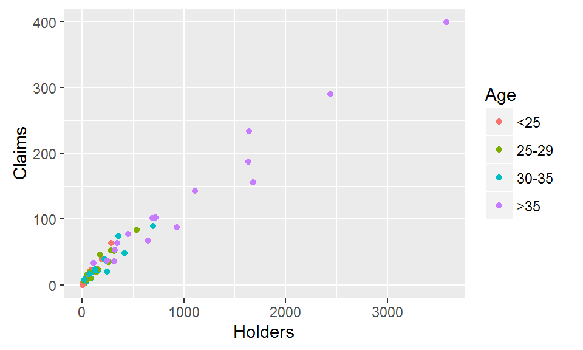

```r
# Add 3rd variable to aesthethics such as colour, size, fill
qplot(Holders, Claims, colour = Age, data = Insurance)
```

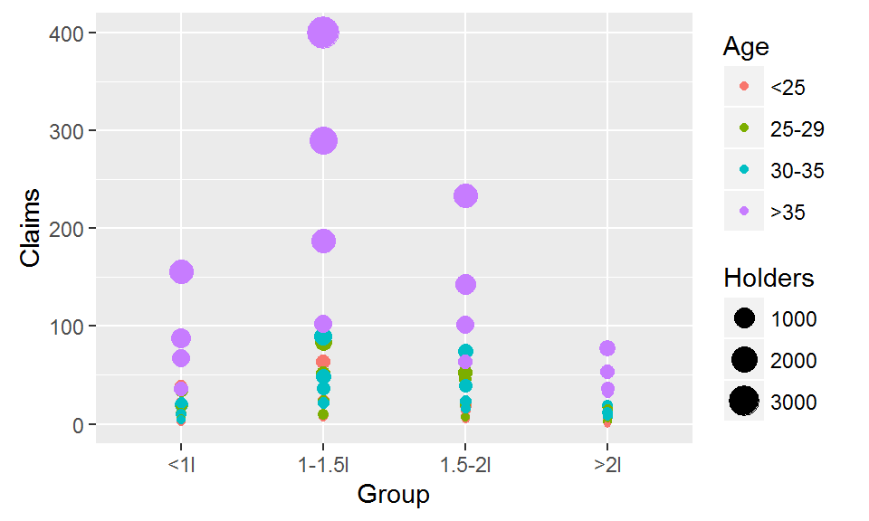

```r
# Don't ever do this, it's very hard to interpret
qplot(Group, Claims, size = Holders, colour = Age, data = Insurance)
```

## qplot: facets

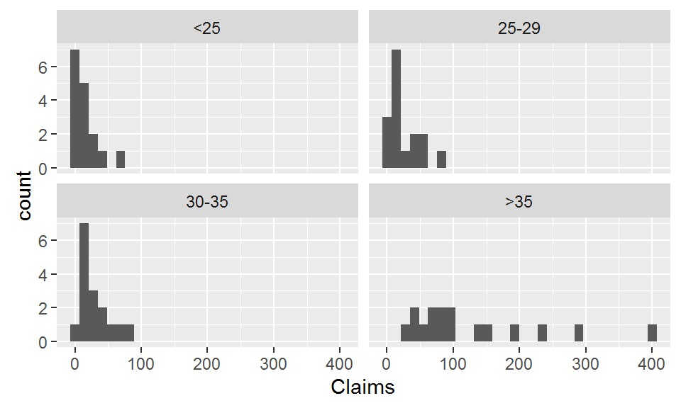

```r
# Facet breaks up a plot by a group.
qplot(Claims, facets = ~ Age, data = Insurance)
```

facets use the `formula` syntax: `~ a` for a single group or `a ~ b` for 2 groups

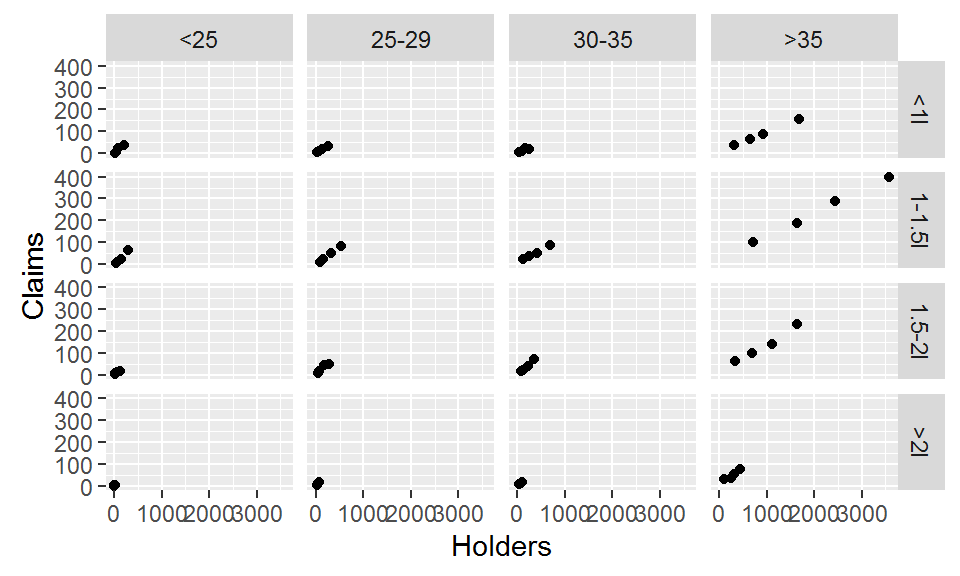

```r
qplot(Holders, Claims, facets = Group ~ Age, data = Insurance)
```

## ggplot()

## ggplot primer

Syntax is confusing at first.

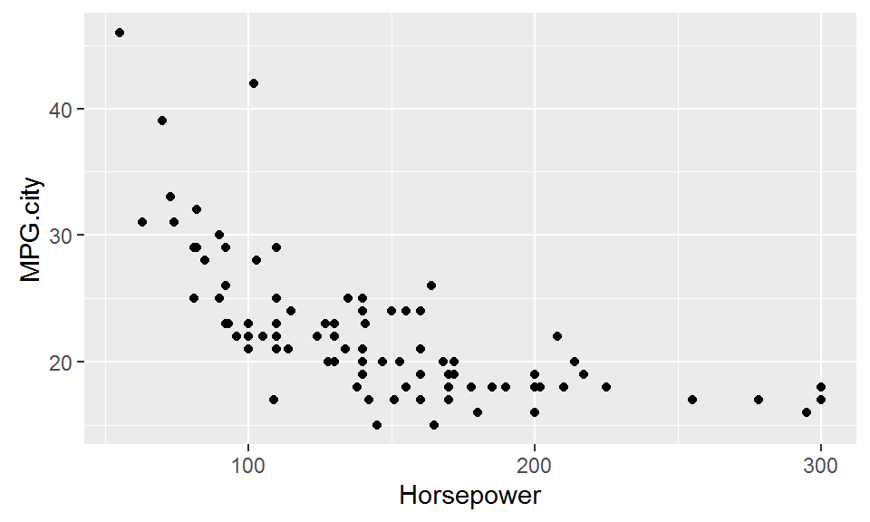

```r
ggplot(data=Cars93, aes(x = Horsepower, y = MPG.city)) +
  geom_point()
```

Basic format is:  
`ggplot(data=YourDataSet, aes(x = IndVariable, y = DepVariable)) + geom_XXXX()`

## ggplot: aesthethics

## aesthethics

- aesthethics are something that the plot draws that varies with data
- examples:
  - colour of a point or line
  - size of a point, or line
  - fill of a bar, histogram
  - shape of a point
- use aes() to define them, either for the whole plot: `ggplot(data = bla, aes(x, y))`
- or for individual layers, if different layers have different aesthethics
  - `geom_line(aes(date, value1, colour = group)) +`  
    `geom_line(aes(date, value2, colour = group))`

## ggplot: aesthethics – examples

## Colour

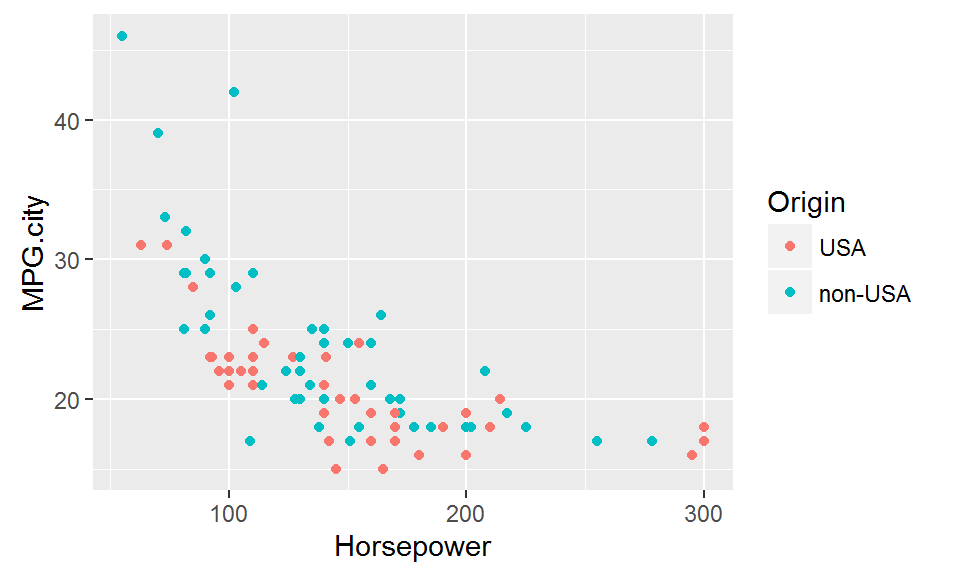

```r
# Position (required) + discrete colour aesthethic
ggplot(data=Cars93, aes(x = Horsepower, y = MPG.city, colour = Origin)) +
  geom_point()
```

## Continous colour

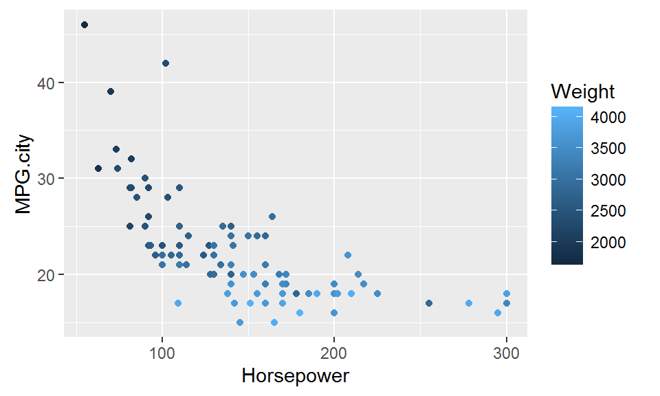

```r
ggplot(data=Cars93, aes(Horsepower, MPG.city, colour = Weight)) +
  geom_point()
```

## Size

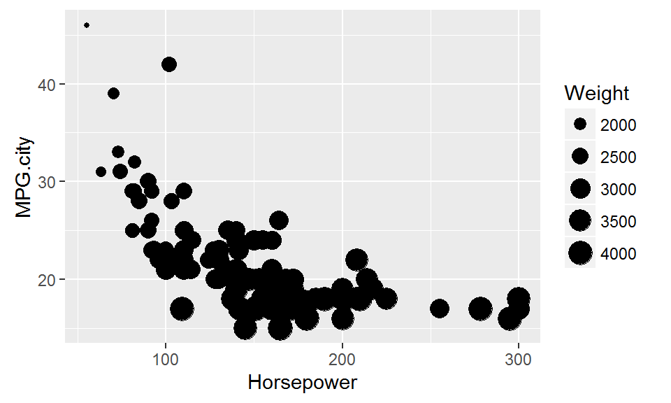

```r
ggplot(data=Cars93, aes(Horsepower, MPG.city, size = Weight)) +
  geom_point()
```

## Fill (histograms)

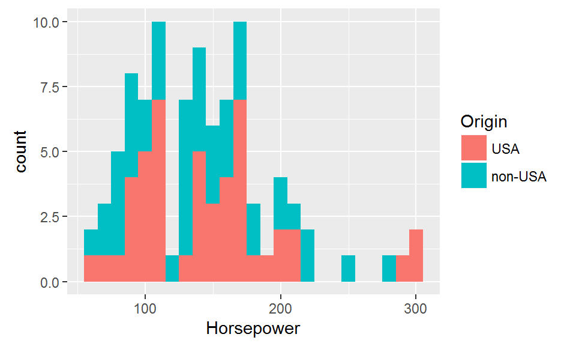

```r
ggplot(data=Cars93, aes(Horsepower, fill = Origin)) +
  geom_histogram(binwidth = 10)
```

## Fill (bars)

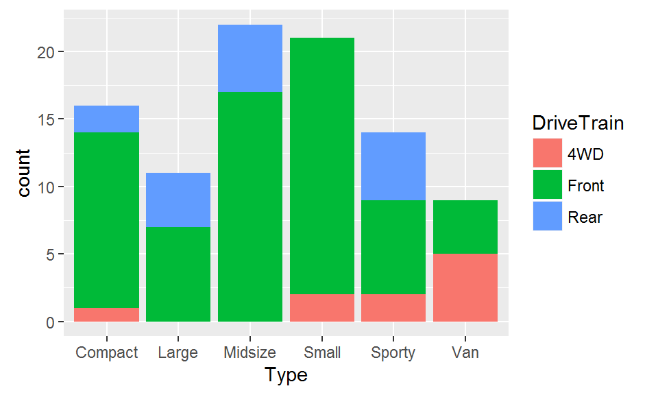

```r
ggplot(data=Cars93, aes(Type, fill = DriveTrain)) +
  geom_bar()
```

## Shape

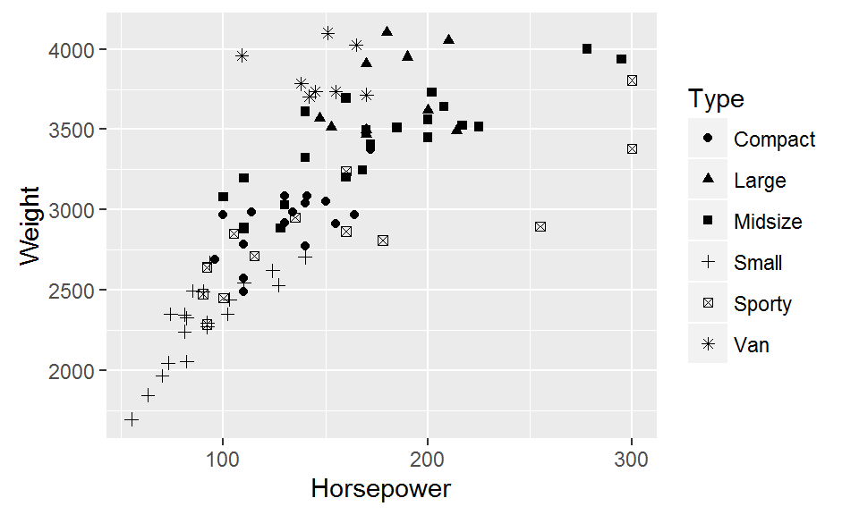

```r
# Not as useful as colour
ggplot(data=Cars93, aes(Horsepower, Weight, shape = Type)) +
  geom_point()
```

## Size

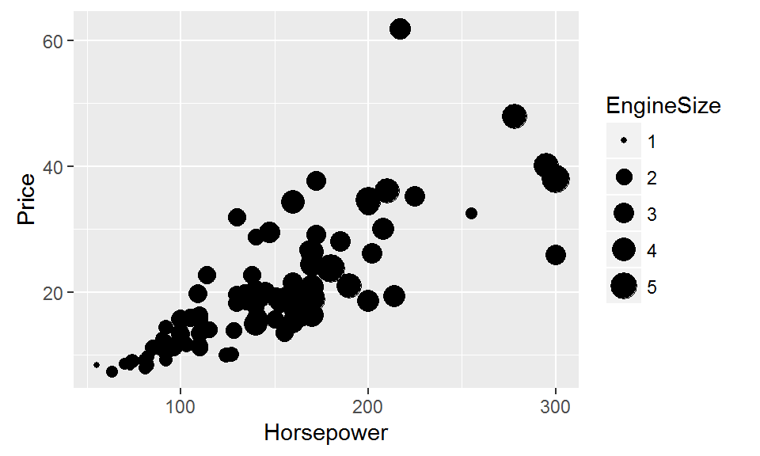

```r
# Size aesthethic
ggplot(data=Cars93, aes(Horsepower, Price, size = EngineSize)) +
  geom_point()
```

## Alpha

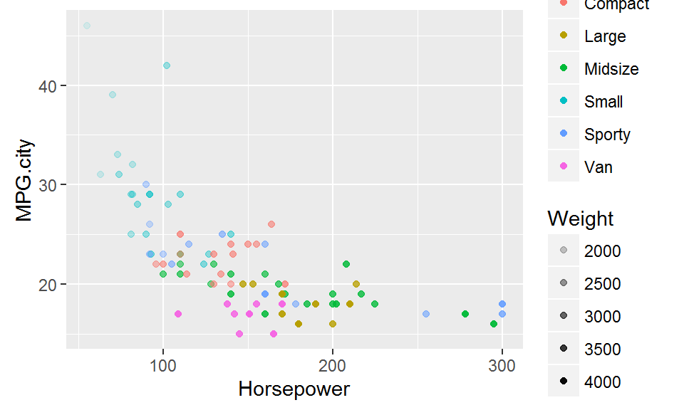

```r
# You can combine multiple aesthethics for multi-dimensional data
# Careful, as 4 dimensions becomes very hard for others to interpret
ggplot(data=Cars93, aes(Horsepower, MPG.city, alpha = Weight, colour = Type)) +
  geom_point()
```

## ggplot: geoms

## Overview of geoms

A geom is a thing that ggplot draws based on data. It will manipulate the data in some way (sometimes) and then draw it on a plot.

The ggplot2 cheatsheet is really helpful here: https://www.rstudio.com/wp-content/uploads/2015/12/ggplot2-cheatsheet-2.0.pdf

## transformations

geoms may transform your data under the hood as needed.

## ggplot geoms: 1 variable (continous)

## histogram

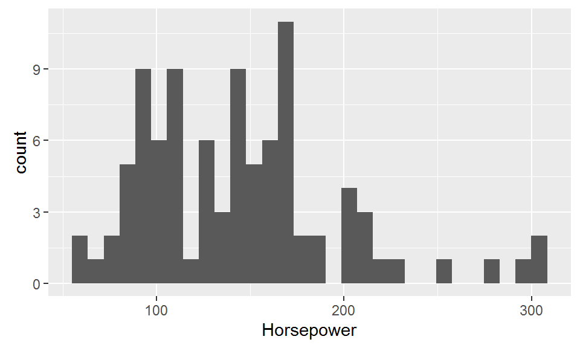

```r
# If you don't provide bins, ggplot2 will (rightly) complain
ggplot(Cars93, aes(Horsepower)) +
  geom_histogram()
```

## with bins

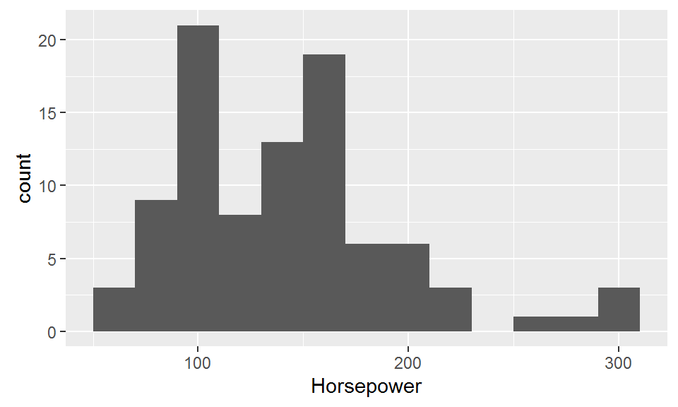

```r
ggplot(Cars93, aes(Horsepower)) +
  geom_histogram(binwidth=20)
```

## freqpoly

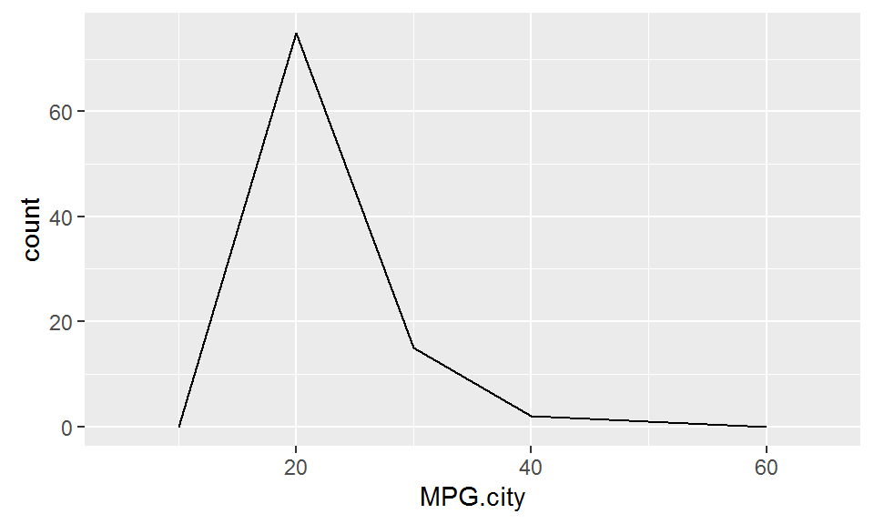

```r
ggplot(Cars93, aes(MPG.city)) +
  geom_freqpoly(binwidth=10)
```

## ggplot geoms: 1 variable (discrete)

## bar charts

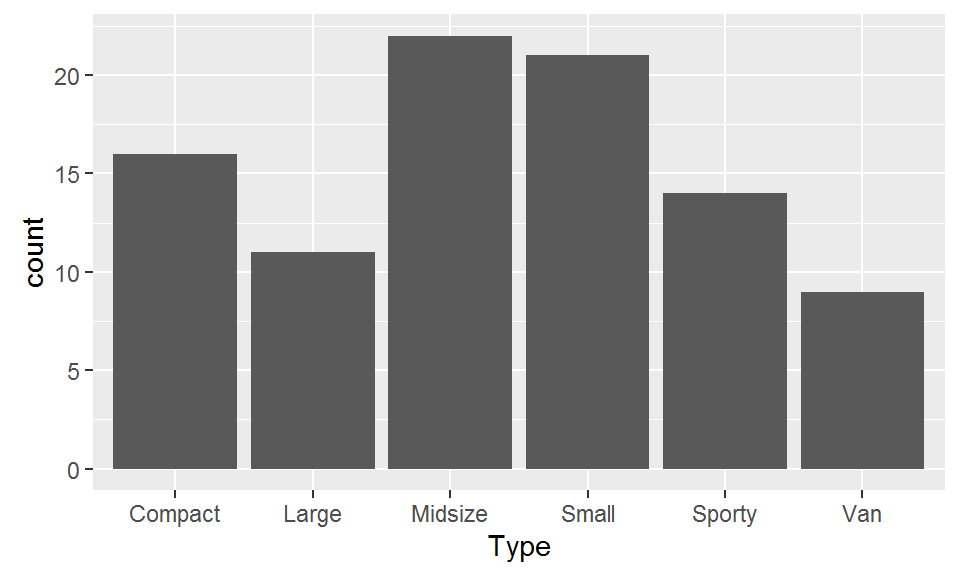

```r
ggplot(Cars93, aes(Type)) +
  geom_bar()
```

## ggplot geoms: 2 variables

## bar chart – weighted

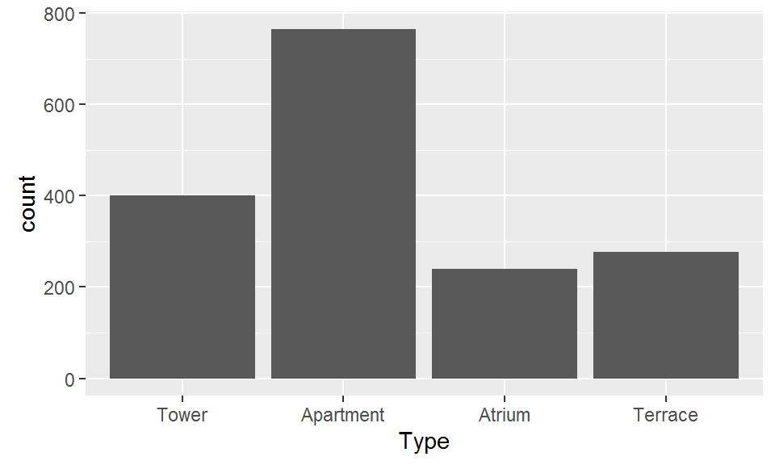

```r
ggplot(housing, aes(Type, weight = Freq)) +
  geom_bar()
```

## bar chart - identity

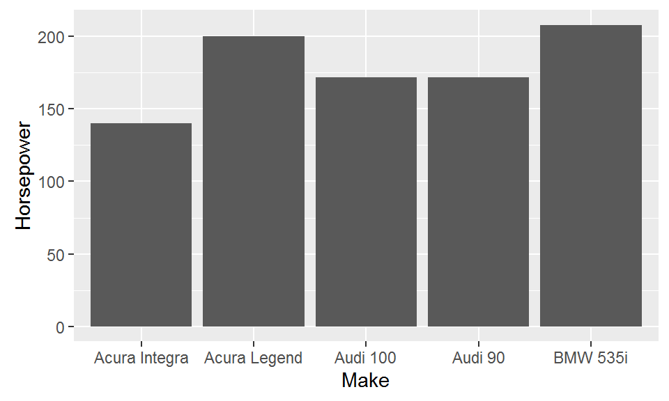

```r
ggplot(Cars93[1:5,], aes(Make, Horsepower)) +
  geom_bar(stat="identity")
```

## point / scatterplot

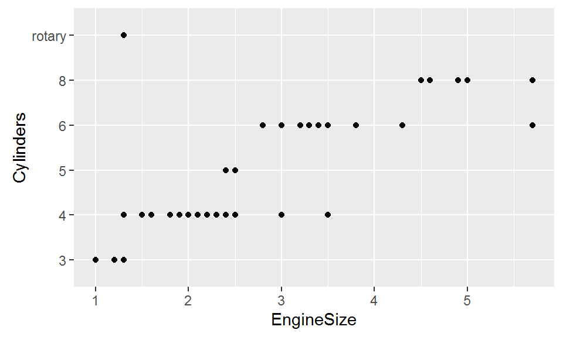

```r
ggplot(Cars93, aes(EngineSize, Cylinders)) +
  geom_point()
```

## jitter

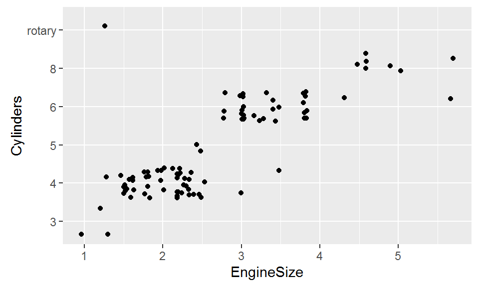

```r
ggplot(Cars93, aes(EngineSize, Cylinders)) +
  geom_jitter()
```

## boxplot

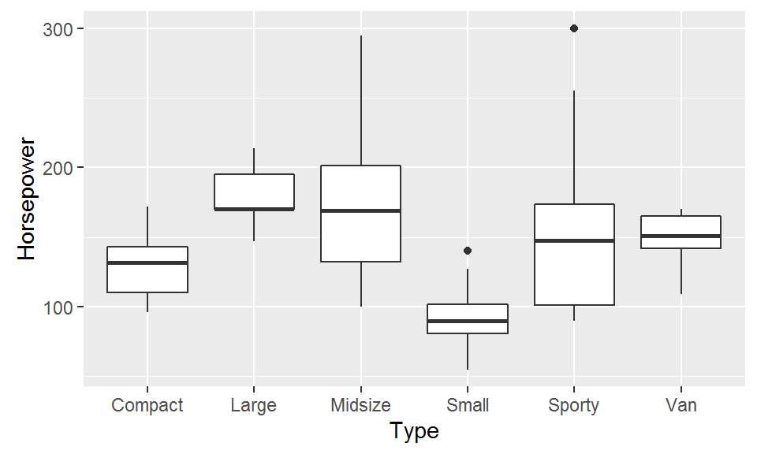

```r
ggplot(Cars93, aes(Type, Horsepower)) +
  geom_boxplot()
```

## line

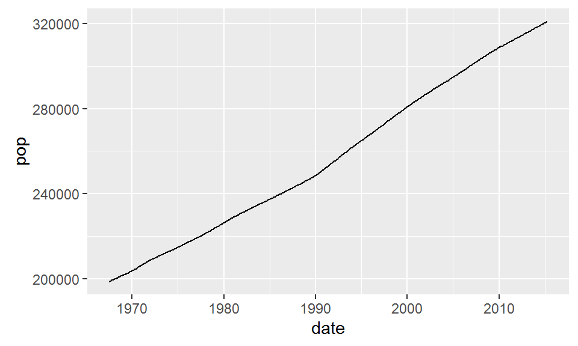

```r
ggplot(economics, aes(date, pop)) +
  geom_line()
```

## multiple lines

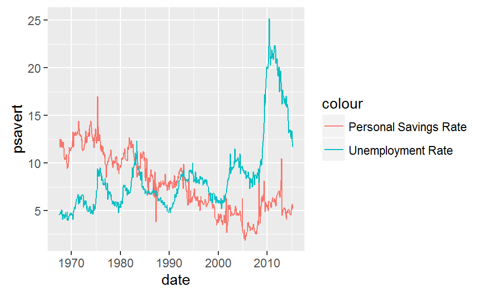

```r
ggplot(economics) +
  geom_line(aes(date, psavert, color = "Personal Savings Rate")) +
  geom_line(aes(date, uempmed, color = "Unemployment Rate"))
```

## smoothing/regression lines

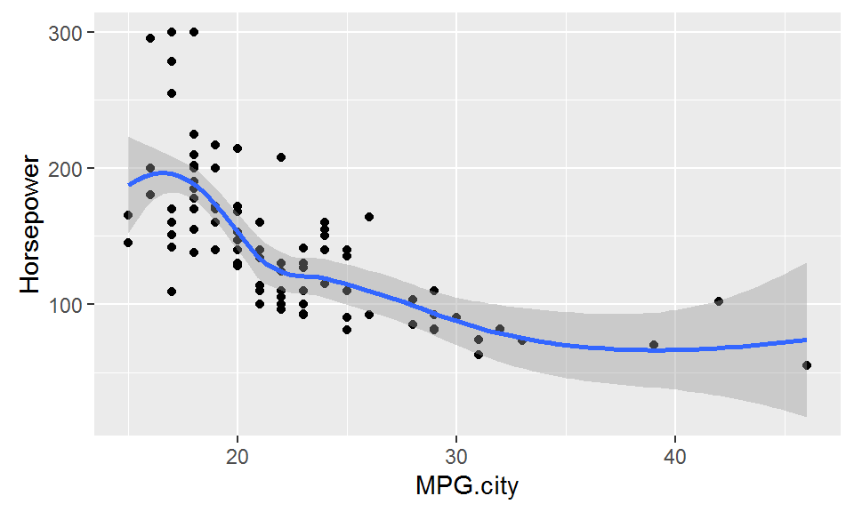

```r
ggplot(Cars93, aes(MPG.city, Horsepower)) +
  geom_point() +
  geom_smooth()
```

## linear lines, without standard error

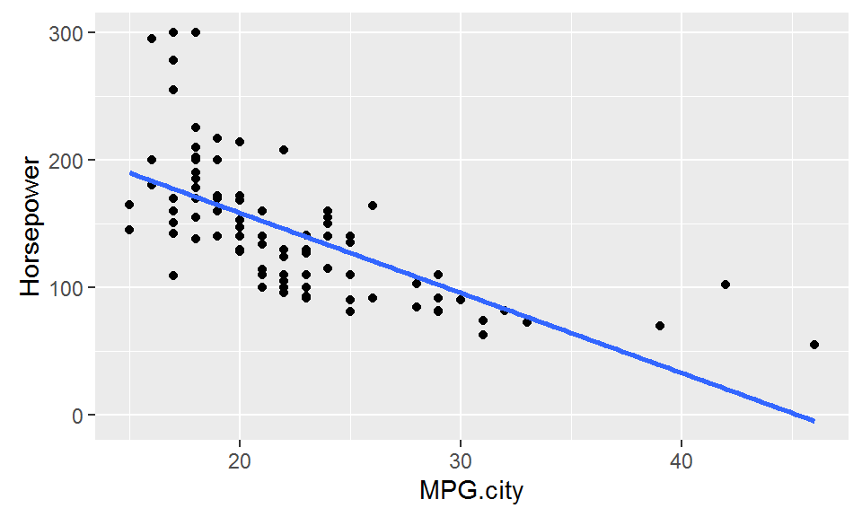

```r
ggplot(Cars93, aes(MPG.city, Horsepower)) +
  geom_point() +
  geom_smooth(method="lm", se=FALSE)
```

## combining geoms

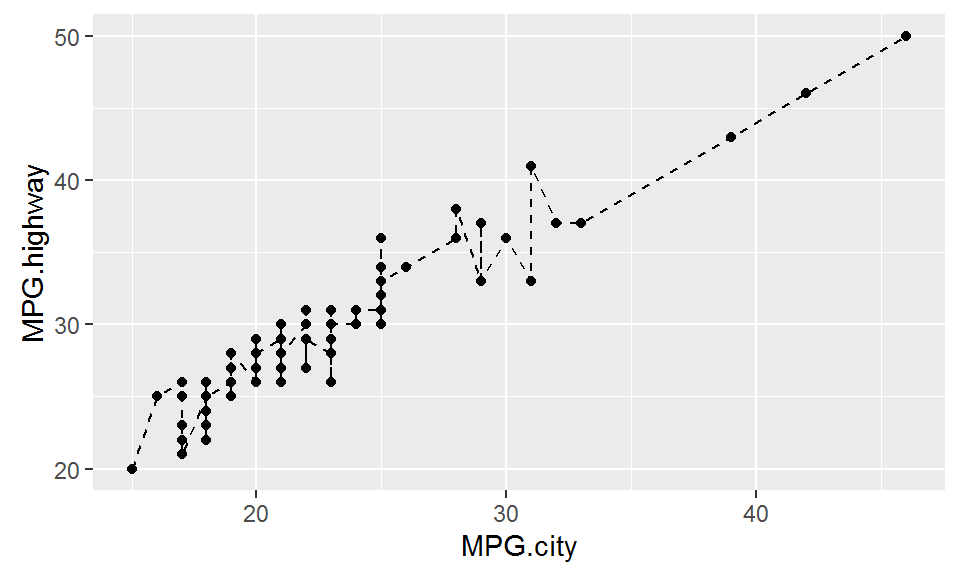

```r
ggplot(Cars93, aes(MPG.city, MPG.highway)) +
  geom_point() +
  geom_line(linetype = 'dashed')
```

## and a complicated exmaple

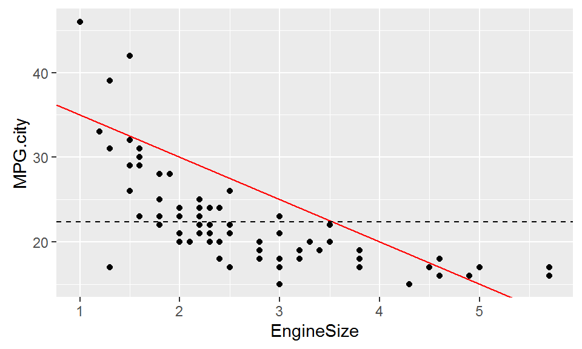

```r
mean_mpg <- mean(Cars93$MPG.city)
ggplot(Cars93, aes(EngineSize, MPG.city)) +
  geom_point() +
  geom_abline(slope = -5, intercept = 40, color = "red") +
  geom_hline(aes(yintercept = mean_mpg), linetype = "dashed")
```